# White Wine Exploratory Data Analysis

# 1. Introduction

I used the “White Wine Quality” dataset. This is a tidy data set and it has a dimension of 4,898 observations of 13 variables. 11 of these variables quantify the chemical properties of each wine. 1 of the variables provides the quality of the wine, rated by at least 3 wine experts between 0 (very bad) and 10 (very excellent). The last variable ‘X’ is an index variable and I did not use it throughout the project. The chemical properties of each wine are independent variables and the quality of the wine is the dependent variable. In this project, I explored the influence of each chemical property on wine quality, and investigated correlations among chemical properties.

```
## 'data.frame':    4898 obs. of  13 variables:
##  $ X                   : int  1 2 3 4 5 6 7 8 9 10 ...
##  $ fixed.acidity       : num  7 6.3 8.1 7.2 7.2 8.1 6.2 7 6.3 8.1 ...
##  $ volatile.acidity    : num  0.27 0.3 0.28 0.23 0.23 0.28 0.32 0.27 0.3 0.22 ...
##  $ citric.acid         : num  0.36 0.34 0.4 0.32 0.32 0.4 0.16 0.36 0.34 0.43 ...
##  $ residual.sugar      : num  20.7 1.6 6.9 8.5 8.5 6.9 7 20.7 1.6 1.5 ...
##  $ chlorides           : num  0.045 0.049 0.05 0.058 0.058 0.05 0.045 0.045 0.049 0.044 ...
##  $ free.sulfur.dioxide : num  45 14 30 47 47 30 30 45 14 28 ...
##  $ total.sulfur.dioxide: num  170 132 97 186 186 97 136 170 132 129 ...
##  $ density             : num  1.001 0.994 0.995 0.996 0.996 ...
##  $ pH                  : num  3 3.3 3.26 3.19 3.19 3.26 3.18 3 3.3 3.22 ...
##  $ sulphates           : num  0.45 0.49 0.44 0.4 0.4 0.44 0.47 0.45 0.49 0.45 ...
##  $ alcohol             : num  8.8 9.5 10.1 9.9 9.9 10.1 9.6 8.8 9.5 11 ...
##  $ quality             : int  6 6 6 6 6 6 6 6 6 6 ...
```

```
## [1] 4898   13
```

# 2. Univariate Plots Section

## 2.1. Distribution of Wine by Quality

As shown in the table below, wine ratings varied from 3 to 9 and no wine was rated below 3 (very bad/ bad) or 10 (excellent). Wine ratings appeared to follow a normal distribution with the most common rating being 6. I created a new variable to split the wines into poor (rated below mean) and good (rated above mean) and we see that there are more wines rated good than poor.

```
##
##    3    4    5    6    7    8    9
##   20  163 1457 2198  880  175    5
```

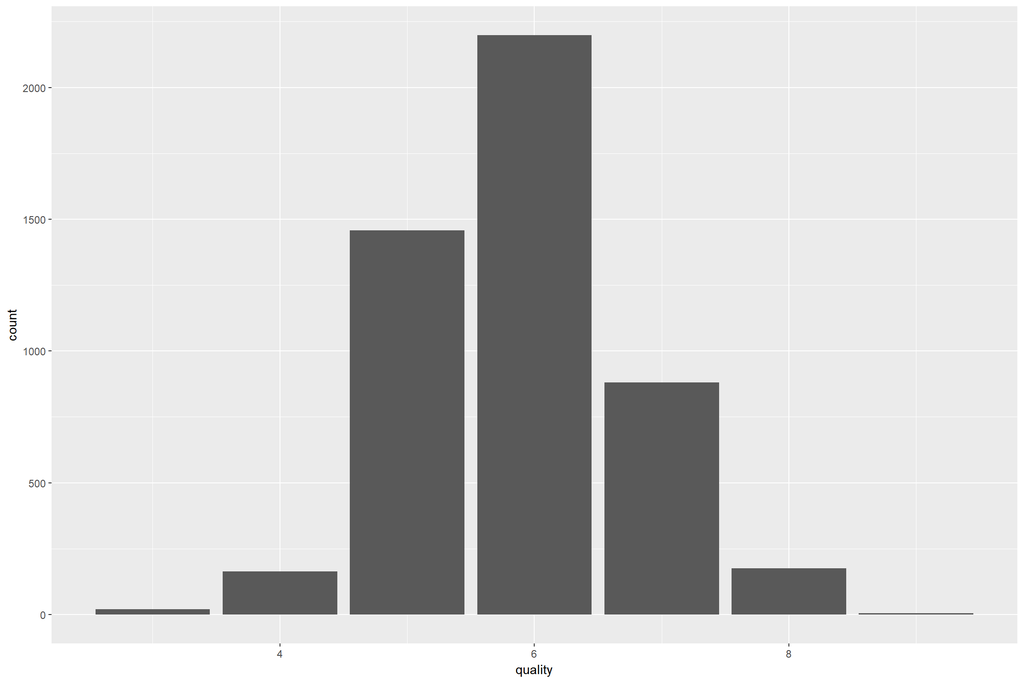

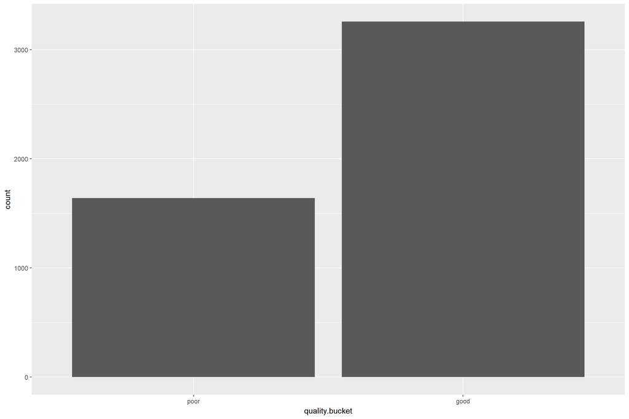

## 2.2. Distribution of Wine by Alcohol Content

Alcohol content did not seem to follow a normal distribution. Intuitively, we know that the balance between grape fermentation level and sweetness varies with origins of wine. For example, wines with low alcohol content are usually from cooler climates like France, Northern Italy and Germany. Wines with medium to high alcohol content are usually from warmer climates like Australia, Americ and Spain.

The histogram indicates that the distribution could be trimodal and be split into three types of alcohol content that is low (0-10%), medium (10%-11.5%), and high(>11.5%). This type of classification would also fit the typical alcohol content classification based on wine origin.

```
##    Min. 1st Qu.  Median    Mean 3rd Qu.    Max.
##    8.00    9.50   10.40   10.51   11.40   14.20
```

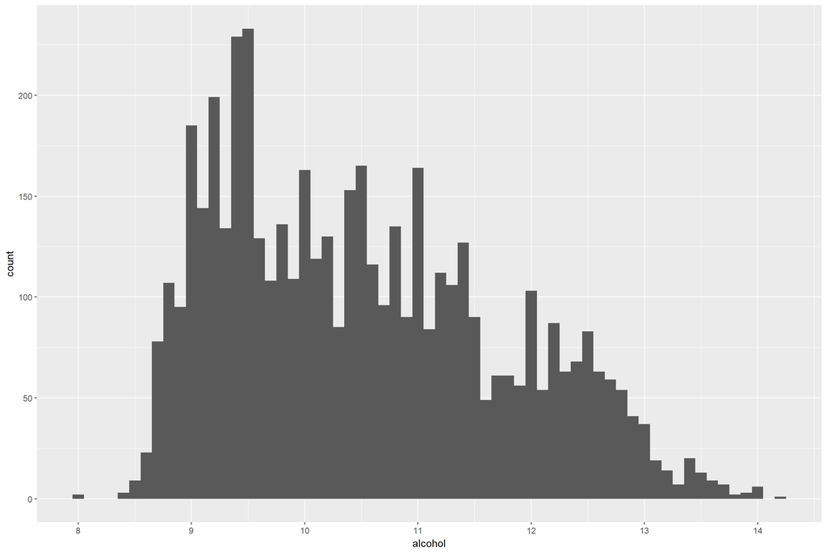

## 2.3. Distribution of Wine by Sulphates

The distribution of wine by sulphates is right-skewed. Plotting the log(sulphates) provides a normal distribution. Internet research indicates that sulphates are added as a preservative and elevated amounts might affect wine quality

```
##    Min. 1st Qu.  Median    Mean 3rd Qu.    Max.
##  0.2200  0.4100  0.4700  0.4898  0.5500  1.0800
```

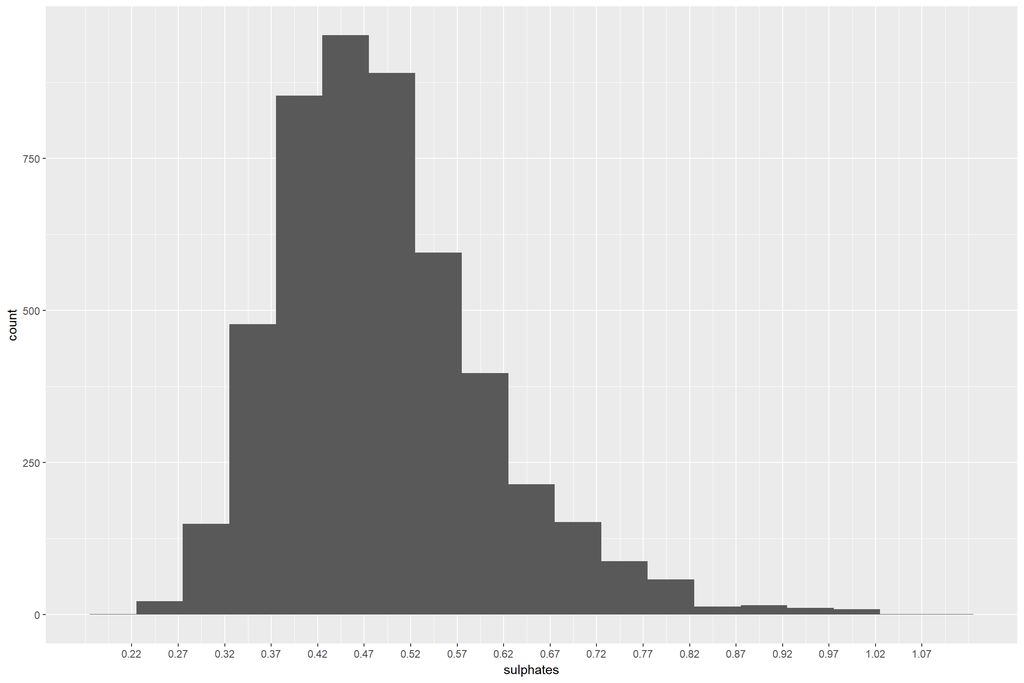

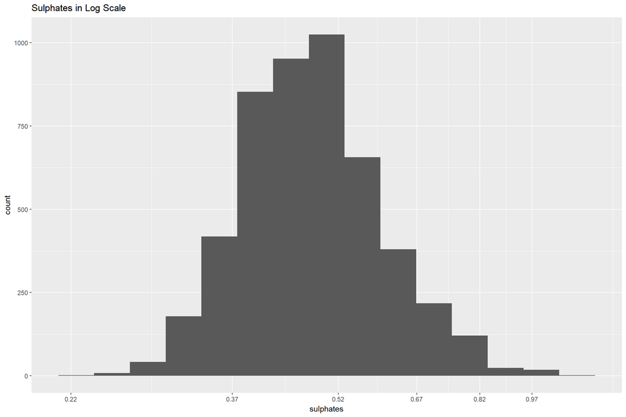

## 2.4. Distribution of Wine by pH

pH follows a normal distribution between a small range of 2.72 and 3.82. Most of the wines have a pH of 3.180. Internet research indicate that the ideal range for white wines should be between 3 and 3.4.

```
##    Min. 1st Qu.  Median    Mean 3rd Qu.    Max.
##   2.720   3.090   3.180   3.188   3.280   3.820
```

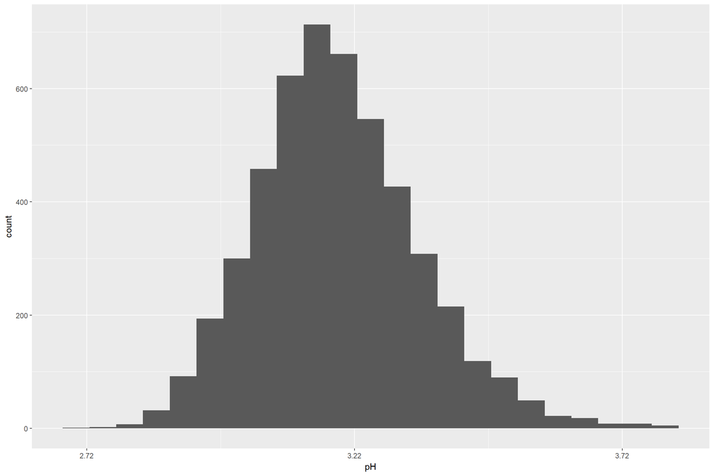

## 2.5. Distribution of Wine by Density

The first visualisation shows that distribution by density follows a normal distribution, except for the presence of some outliers with high density.

```
##    Min. 1st Qu.  Median    Mean 3rd Qu.    Max.
##  0.9871  0.9917  0.9937  0.9940  0.9961  1.0390
```

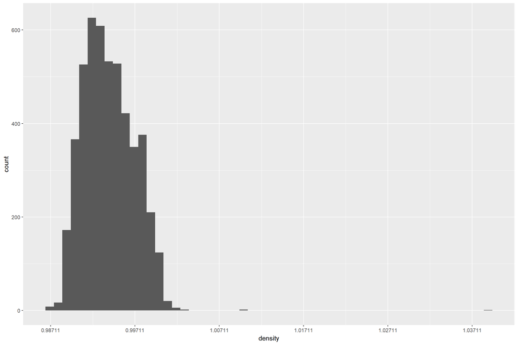

A table of quality ratings of those wines with a density higher than 99% quantile is shown below. There is no indication that the higher density had influenced the quality ratings, as most of the densest wines are still rated 5 or 6 and the wine ratings occupy a full range from 4-8. More of this relationship will be analyzed in the bivariate analysis portion.

```
## .
##  4  5  6  7  8
##  1 20 25  1  2
```

## 2.6. Distribution of Wine by Total Sulfur Dioxide

The first visualisation shows that distribution by total sulfur dioxide follows a normal distribution, except for the presence of some outliers with a high total sulfur dioxide content.

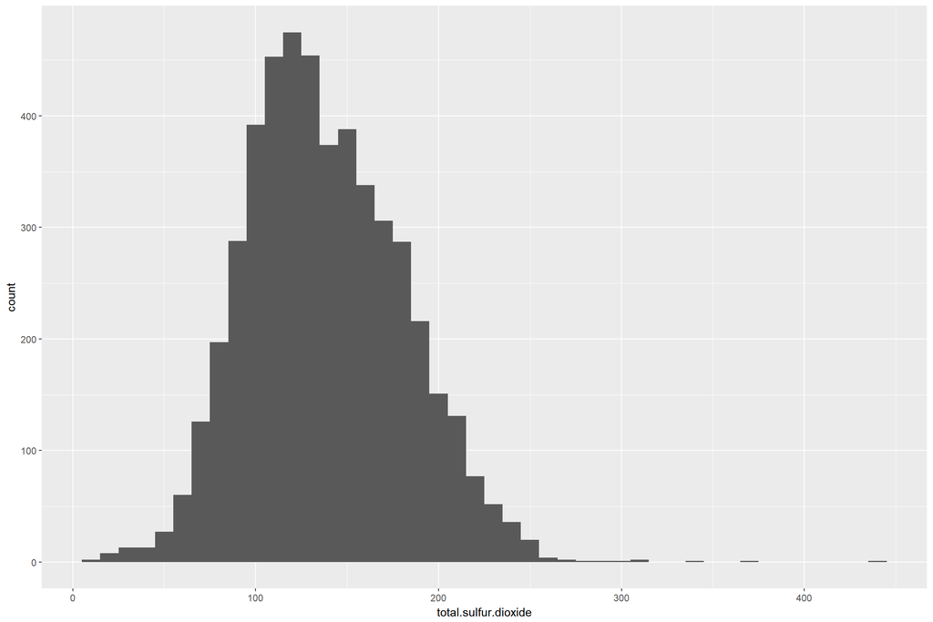

A table of quality ratings of those wines with a total sulfur dioxide content higher than 99% quantile is shown below. There is some indication that the higher content had influenced the quality ratings, as most of the wines are rated average or below. More of this relationship will be analyzed in the bivariate analysis portion

```
## .
##  3  4  5  6
##  3  2 22 22
```

## 2.7. Distribution of Wine by Free Sulfur Dioxide

The first visualisation shows that distribution by free sulfur dioxide follows a normal distribution, except for the presence of outliers with a high free sulfur dioxide content.

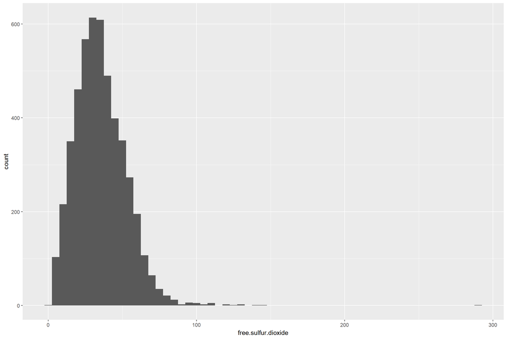

A table of quality ratings of those wines with a free sulfur dioxide content higher than 99% quantile is shown below. There is no indication that the higher content has influenced the quality ratings, as most of the wines are rated 5 or 6 and occupies a full quality range of 3-8. More of this relationship will be analyzed in the bivariate analysis portion

```
## .
##  3  4  5  6  7  8
##  4  2 12 17  4  4
```

## 2.8. Distribution of Wine by Bound Sulfur Dioxide

Here, I made a new variable for Bound Sulfur Dioxide that was calculated as the difference between total and free sulfur dioxide. The visualisation shows that distribution by bound sulfur dioxide follows a normal distribution, except for the presence of outliers with a high bound sulfur dioxide content.

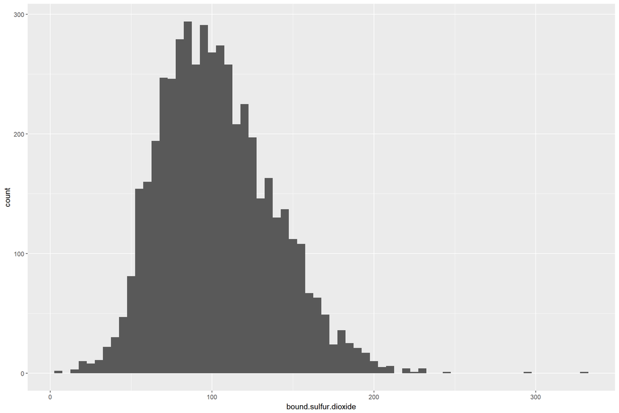

A table of quality ratings of those wines with a bound sulfur dioxide content higher than 99% quantile is shown below. There is no indication that the higher content has influenced the quality ratings, as most of the wines are rated 5 or 6 and occupies a full quality range of 3-7. More of this relationship will be analyzed in the bivariate analysis portion

```
## .
##  3  4  5  6  7
##  2  1 21 22  1
```

## 2.9. Distribution of Wine by Ratio of Free to Bound Sulfur Dioxide

Here, I made a new variable for the ratio of Free to Bound Sulfur Dioxide. Internet research indicates that most of the bound sulfur dioxide is not available to act as a preservative to the wine. A good wine would typically have a high ratio of free to bound Sulfur Dioxide, which we will investigate in the bivariate analysis section of this project.

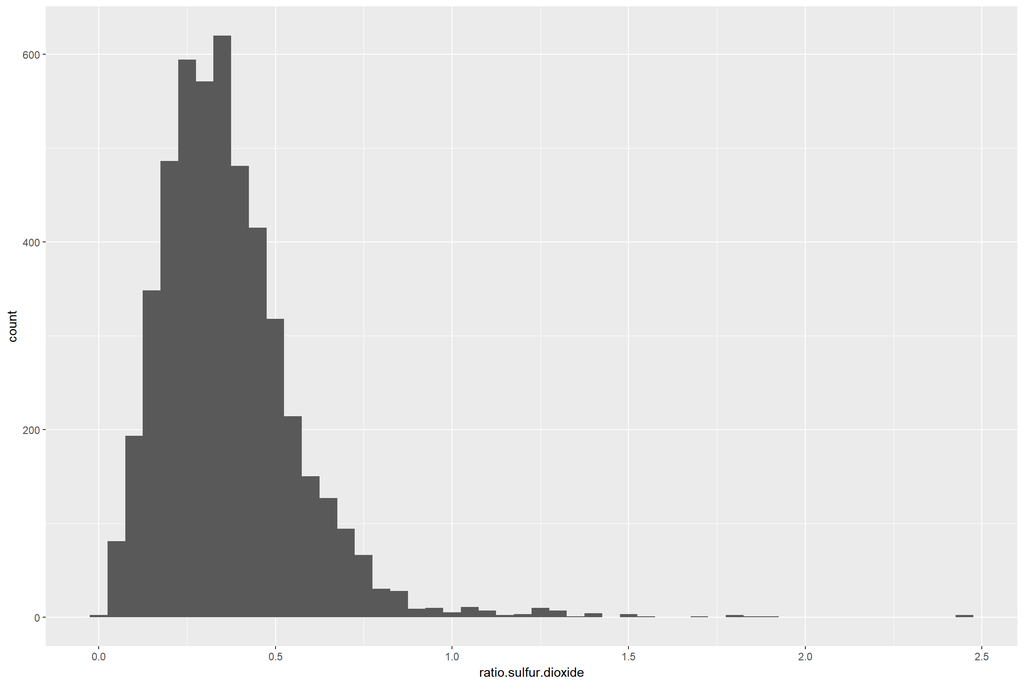

## 2.10. Distribution of Wine by Chlorides

The distribution appears to be normally distributed around 0 g/dm^3 to 0.1 g/dm^3. There are outliers in this distribution, which should make the wine taste saltier.

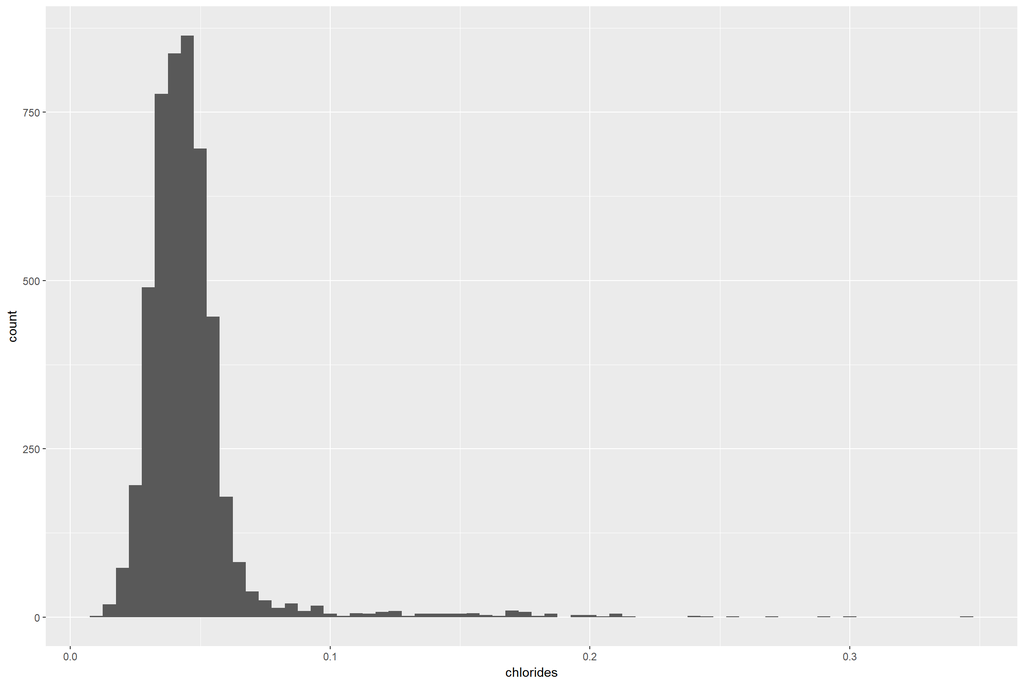

A table of quality ratings of those wines with chloride content higher than 99% quantile is shown below. There is an indication that the higher chloride content had influenced the quality ratings, as the wines are rated average or below. More of this relationship will be analyzed in the bivariate analysis portion

```
## .
##  3  4  5  6
##  1  1 24 22
```

## 2.11. Distribution of Wine by Residual Sugar

The distribution of wine by log(residual sugar) appears to be bimodally distributed around 1.6 g/dm^3 and 8 g/dm^3. This indicates that the wines could be split into two categories of sweet and not_sweet. After bucketing the wines into two groups of sweet vs not_sweet, we see that there are more sweet wine than non-sweet wine.

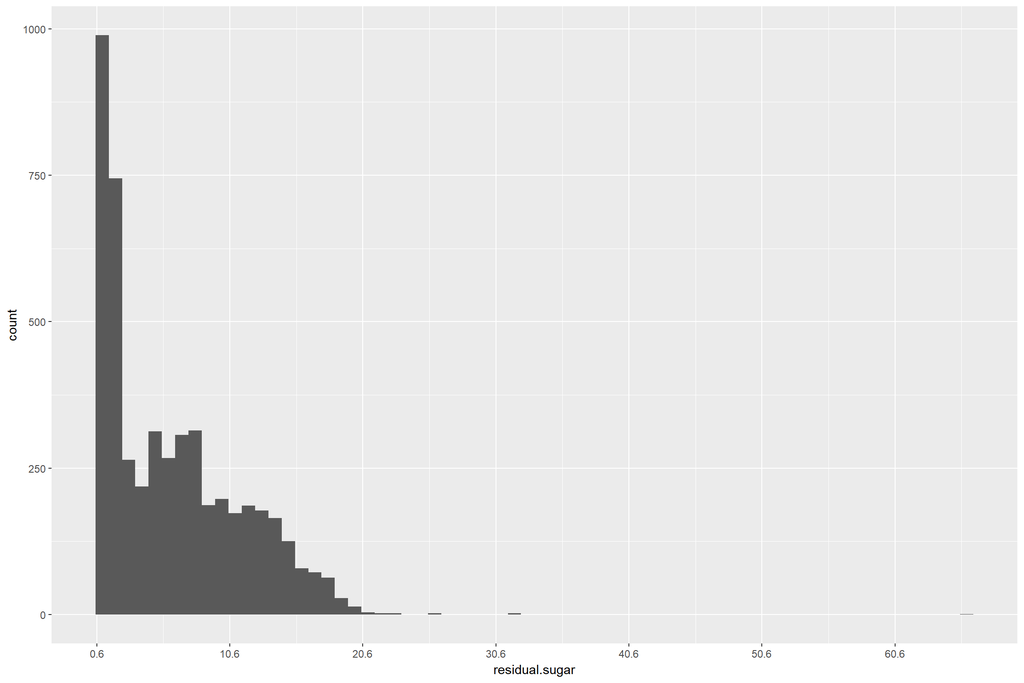

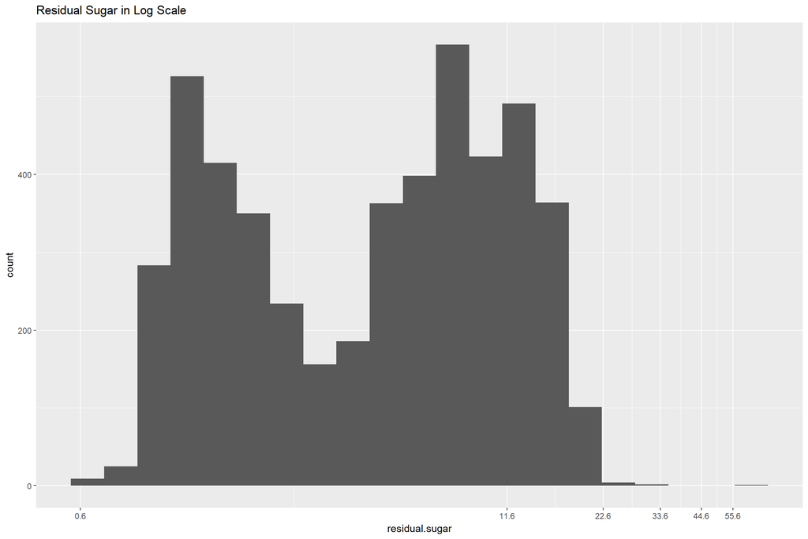

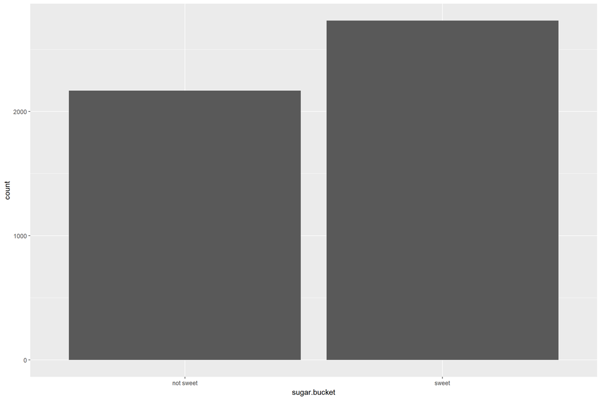

## 2.12. Distribution of Wine by Citric Acid

The distribution of wine by citric acid appears to be normally distributed with some outliers.

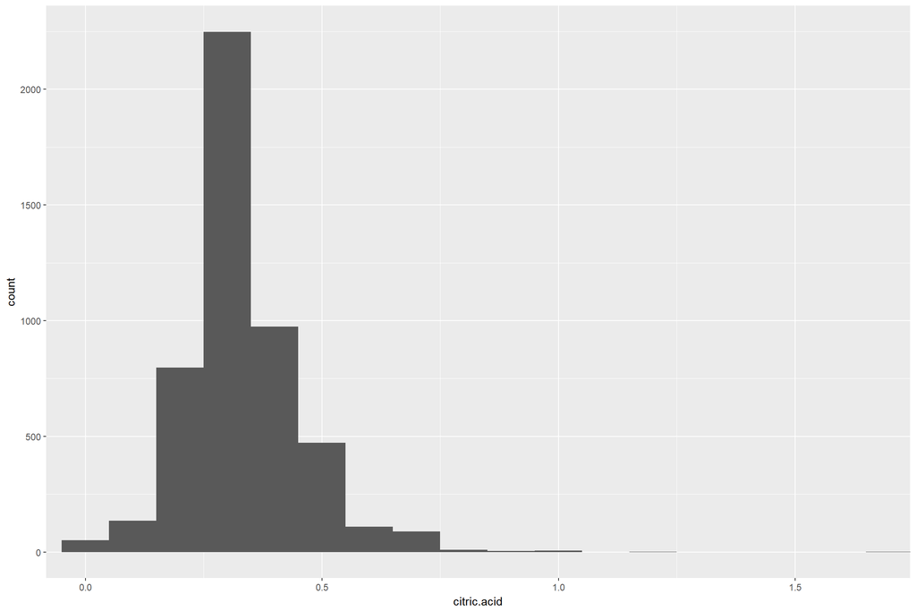

A table of quality ratings of those wines with citric acid content higher than 99% quantile is shown below. There is an indication that the higher citric acid content had influenced the quality ratings, as the wines are rated average or below. More of this relationship will be analyzed in the bivariate analysis portion

```
## .
##  4  5  6
##  1  8 13
```

## 2.13. Distribution of Wine by Volatile Acidity

The distribution of wine by volatile acid appears to be right skewed. The distribution by log(volatile acid) appears to follow a normal distribution

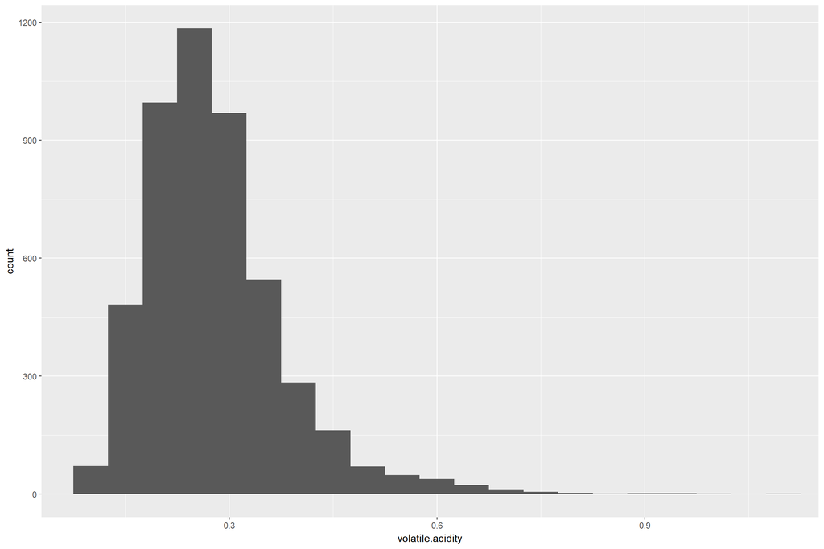

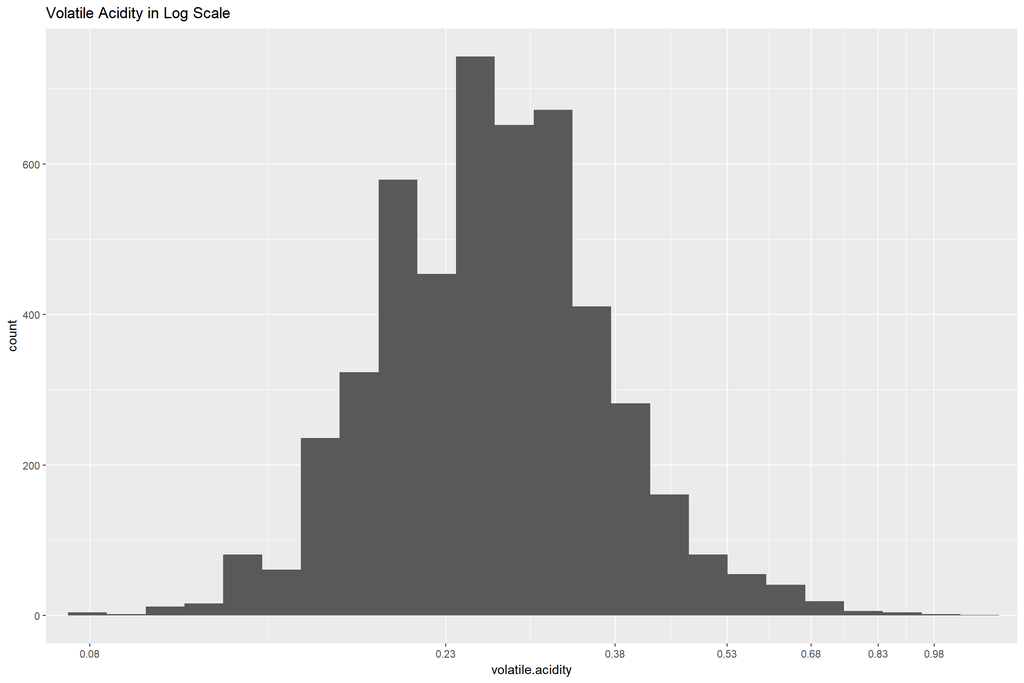

## 2.14. Distribution of Wine by Fixed Acidity

The distribution of wine by fixed acidity appears to be normally distributed.

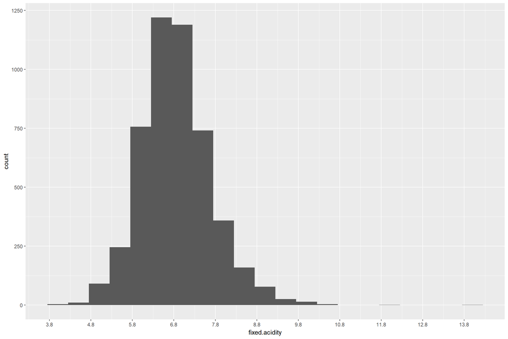

## 2.15. Univariate Analysis

**What is the structure of your dataset?**

There are 4898 observations of 13 variables. One of the variable is an index and ignored in the analysis. 11 variables are independent variables describing chemical properties of the wine, while 1 of the varibale is the dependent variable stating the average rating of wine quality given by three wine experts.

**What is/are the main feature(s) of interest in your dataset?**

The main feature of interest is quality. All other features are chemical properties which might influence the quality of the wine.

**What other features in the dataset do you think will help support your investigation into your feature(s) of interest?**

According to the above preliminary explorations, there seems to be some indication that amount of chlorides, citric acid and total sulfur dioxide has an influence on quality of wine.

**Did you create any new variables from existing variables in the dataset?**

I created the bound sulfur dioxide variable to determine the ratio of free to bound sulfur dioxide as there was indication from online internet research that the ratio of free to bound sulfur dioxide might influence quality. I also created factor variables for residual sugar (sweet and non-sweet) and quality (poor and good).

**Of the features you investigated, were there any unusual distributions? Did you perform any operations on the data to tidy, adjust, or change the form of the data? If so, why did you do this?**

Alcohol content seemed to be trimodally distributed, which might map to wines with low, medium and high alcohol content. I also adjusted the histogram of residual sugar content and found that the log(residual sugar) is bimodally adjusted, which might map to sweet and non-sweet wines.

# 3. Bivariate Plots Section

## 3.1. Correlation Matrix of Variables

Below is a visualisation of the correlation between variables in the dataset. We see that quality is most correlated with **density and alcohol** content.

- **Negative Correlation**
- Alcohol and Density
- Alcohol and Residual Sugar
- pH and Fixed Acidity
- Alcohol and Total Sulfur Dioxide
- **Positive Correlation**
- Residual Sugar and Density
- Density and Total Sulfur Dioxide
- Total and Free Sulfur Dioxide

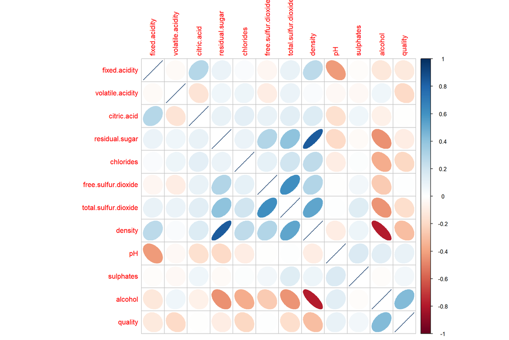

## 3.2. Boxplots of Chemical Properties vs Wine Quality

The correlation matrix only showed obvious correlation between quality, and density and alcohol content. Here, I averaged the data for wines rated below average (poor) and above average (good) and found the following general patterns.

- **Good wines have higher of the following**
- Alcohol
- Sulphates
- pH
- Ratio of free to bound sulfur dioxide
- **Good wines have lower of the following**
- Density
- Chlorides
- Residual Sugar
- Volatile Acidity

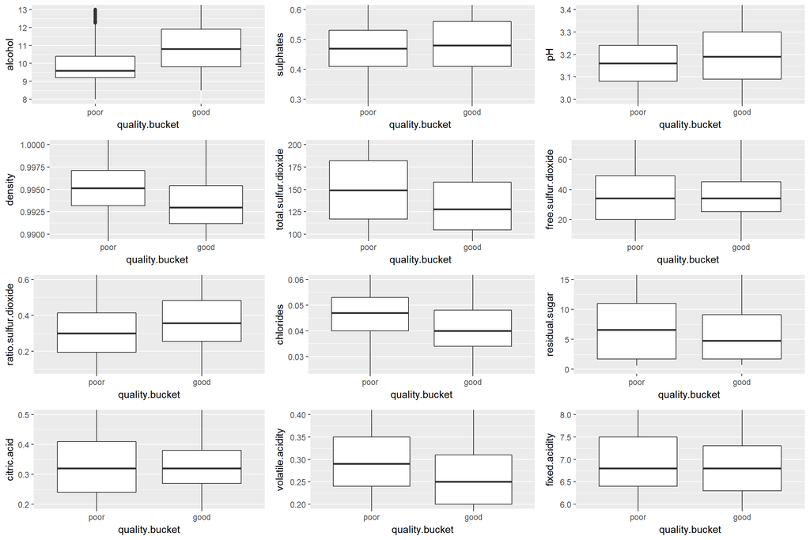

## 3.3. Quality vs Alcohol

Correlation betwen quality and alcohol content i 0.436, which indicates a positive association between the two variables. This is also confirmed in the scatter plot between quality and alcohol content.

```
## [1] "Correlation =  0.435574715461373"
```

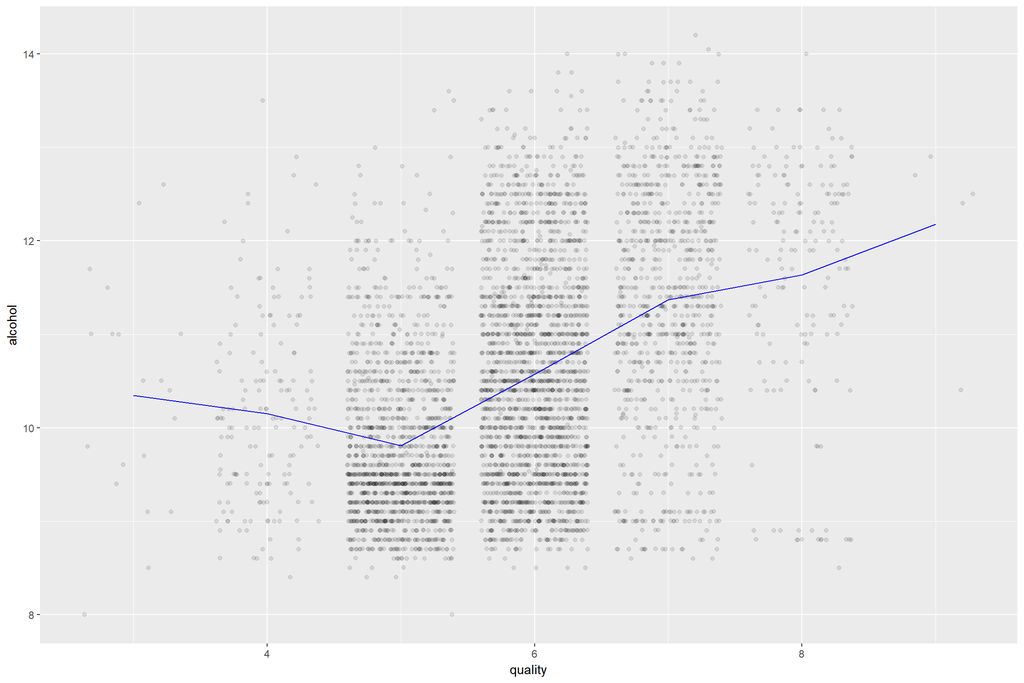

## 3.4. Density vs Alcohol Content

Correlation betwen alcohol and density is -0.780, which indicates a strong negative association between the two variables. This is also confirmed in the scatter plot between alcohol and density. This is expected since alcohol has a lower density than water and increasing alcohol will decrease density.

```
## [1] "Correlation =  -0.780137621425558"
```

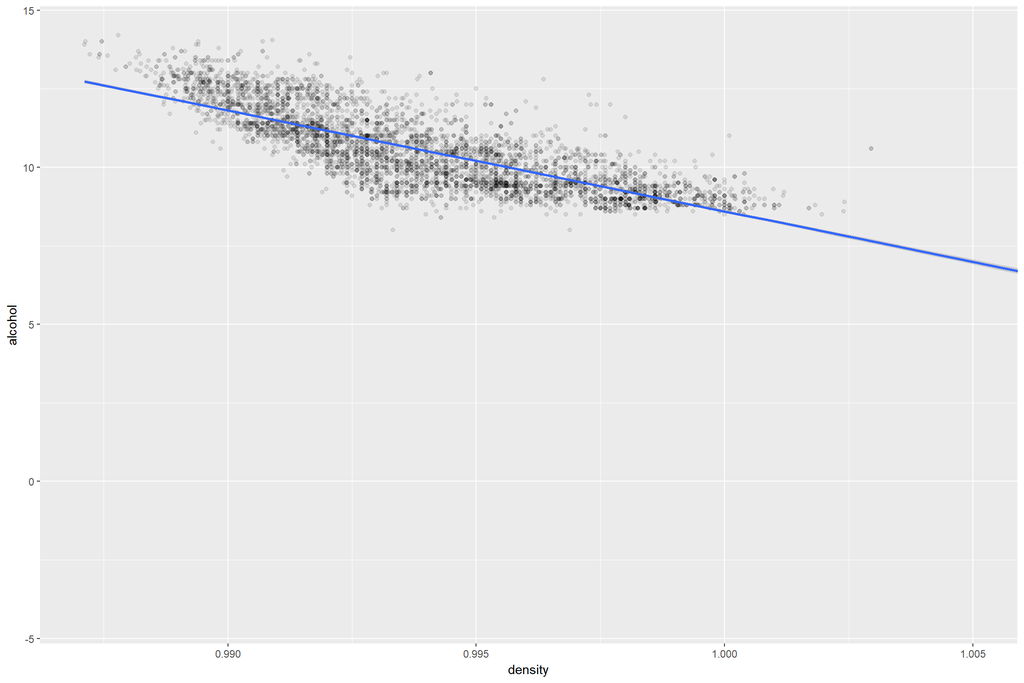

## 3.5. Residual Sugar vs Alcohol Content

Correlation betwen alcohol and residual sugar is -0.450, which indicates a slight negative association between the two variables. This is also confirmed in the scatter plot between alcohol and residual sugar. This is expected since yeast eats sugar from the grapes and makes alcohol as a by-product. A sweet wine is made when the yeast is stopped before it eats all the sugar and produces less alcohol.

```
## [1] "Correlation =  -0.450631222031729"
```

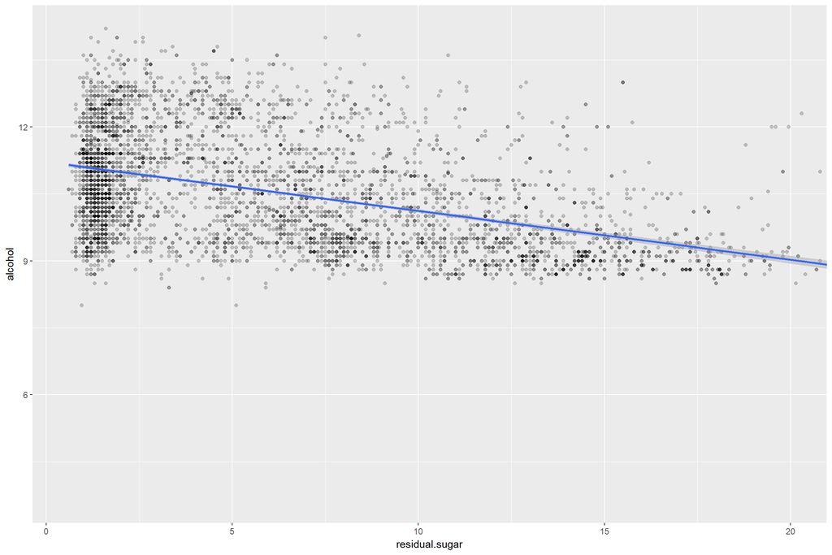

## 3.6. Density vs Residual Sugar

Correlation betwen density and residual sugar is 0.839, which indicates a strong positive association between the two variables. This is also confirmed in the scatter plot between density and residual sugar. This is expected since alcohol content reduces density, and residual sugar is an indication of when yeast fermentation and alcohol fermentation stopped.

```
## [1] "Correlation =  0.838966454904583"
```

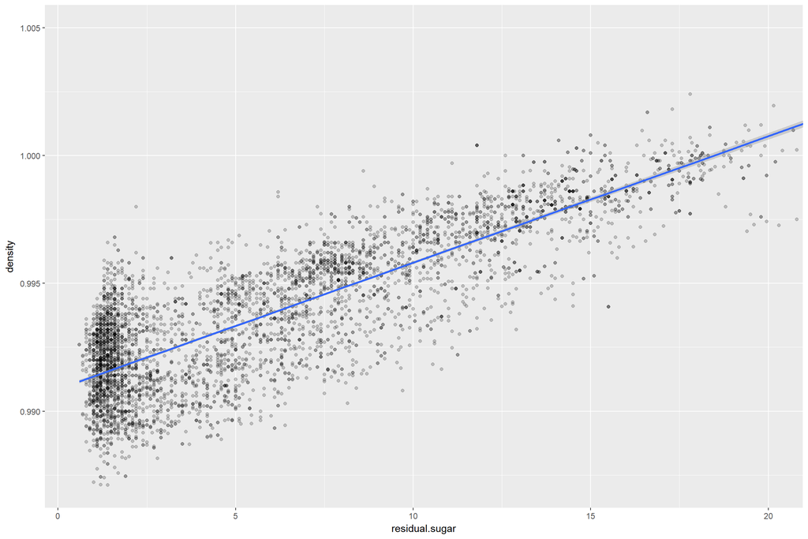

## 3.7. pH vs Fixed Acidity

Correlation betwen pH and fixed acidity is -0.426, which indicates a negative association between the two variables. This is also confirmed in the scatter plot between pH and fixed acidity. pH decreases with increasing acidity and so it is not surprising that we find this correlation. In addition, correlation between pH and the acidic components is the strongest for fixed acidity because it has the largest proportion of the three components.

```
## [1] "Correlation =  -0.425858290991382"
```

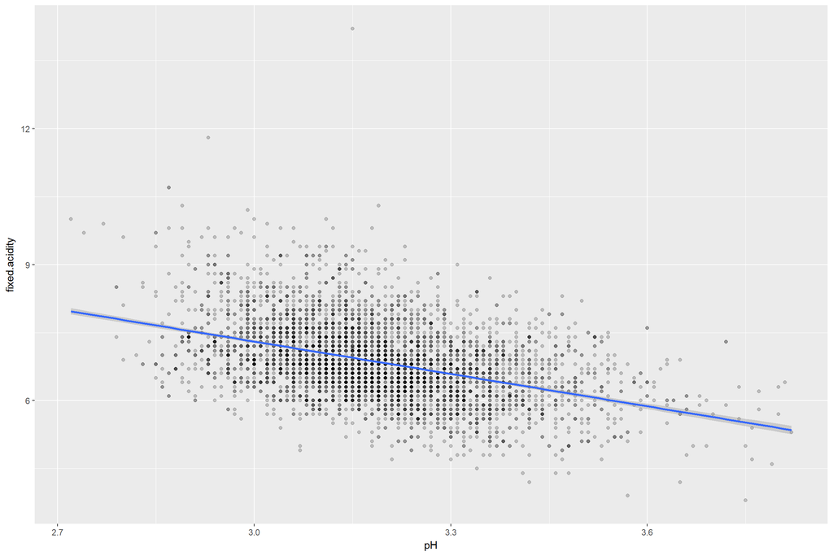

## 3.8. Alcohol vs Total Sulfur Dioxide

Correlation betwen alcohol and total sulfur dioxide is -0.449, which indicates a negative association between the two variables. This is also confirmed in the scatter plot between alcohol and total sulfur dioxide. This is surprising and probably points to some underlying chemistry between the two variables.

```
## [1] "Correlation =  -0.448892102061342"
```

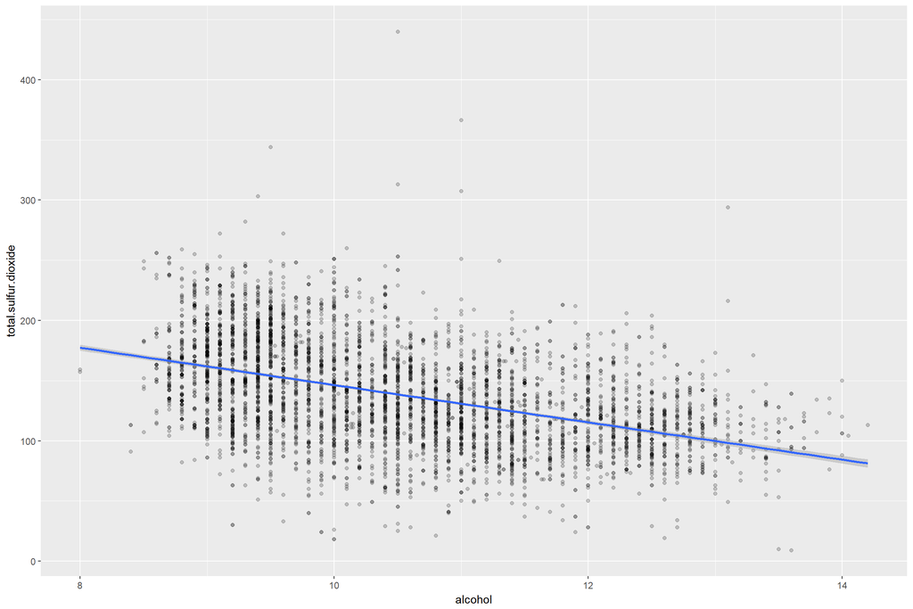

## 3.9. Density vs Total Sulfur Dioxide

Correlation betwen density and total sulfur dioxide is 0.530, which indicates a positive association between the two variables. This is also confirmed in the scatter plot between density and total sulfur dioxide. This follows from the previous section since density and alcohol are strongly correlated.

```
## [1] "Correlation =  0.529881323878611"
```

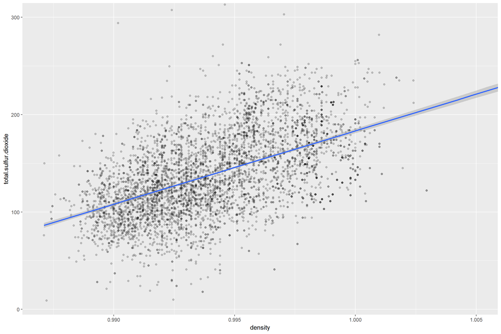

## 3.10. Free vs Total Sulfur Dioxide

Correlation betwen free and total sulfur dioxide is 0.616, which indicates a positive association between the two variables. This is also confirmed in the scatter plot between free and total sulfur dioxide. This is expected because total sulfur dioxide is the sum of free and bound sulfur dioxide.

```
## [1] "Correlation =  0.615500965009836"
```

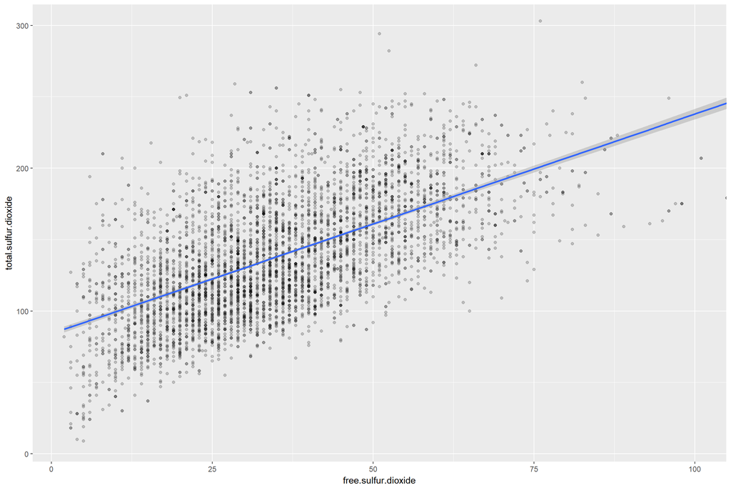

## 3.11. Bivariate Analysis

**Talk about some of the relationships you observed in this part of the investigation. How did the feature(s) of interest vary with other features in the dataset?**

The main feature of interest, quality was most influenced by alcohol content, and by association the features correlated with alcohol content. It seemed that drier (non-sweet) wines with higher alcohol content tended to be rated higher. Quality was less influenced by the other variables, but some general trends could be observed by grouping data for wines rated below and above average.

- **Good wines have higher of the following**
- Alcohol
- Sulphates
- pH
- Ratio of free to bound sulfur dioxide
- **Good wines have lower of the following**
- Density
- Chlorides
- Residual Sugar
- Volatile Acidity

**Did you observe any interesting relationships between the other features (not the main feature(s) of interest)?**

Density, alcohol content, and residual sugar are correlated with one another because of the chemistry involved. pH and fixed acidity is also strongly correlated. A surprising relationship exists between total sulfur dioxide and alcohol content and may need further chemistry for explanation.

# 4. Multivariate Plots Section

## 4.1. Total Sulfur Dioxide vs Alcohol, and Quality

Here we investigate further the relationship between total sulfur dioxide and alcohol content, layered with quality data. The below graph confirms previous observations that wines with greater alcohol content are rated higher and that total sulfur dioxide is correlated with alcohol content. In additon, the graph shows that wines with a moderate total sulfur dioxide content are rated higher compared to those with high or low total sulfur dioxide content. While sulfur dioxide acts as preservative and maintains the wine’s integrity, high amounts of sulfur dioxide becomes evident in the taste and smell of the wine and could lead to a lower rating.

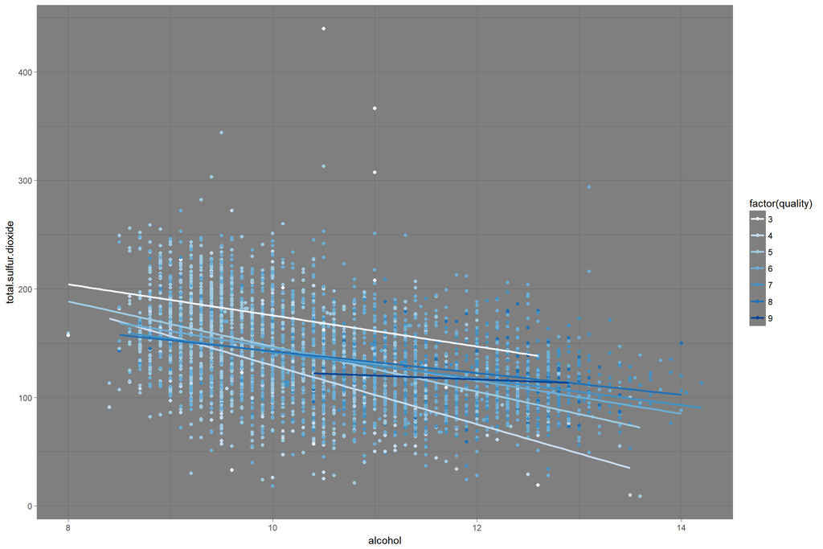

## 4.2. Chlorides vs Residual Sugar, and Quality

Here we investigate the salty taste imparted by the chlorides and the residual sugar, layered with quality. The graph confirms previous observations that good wines tend to have lower chloride levels and residual sugar level. In addition, the graph also show a positive correlation between chlorides and sugar for wines that are rated at low levels 3 and 4, and high levels 8 and 9. For example, the correlation between chlorides and residual sugar is 0.089 for the full dataset, but is at 0.431 for wines that are rated 9.

```
## [1] "Correlation for overall dataset =  0.0886845359412256"
```

```
## [1] "Correlation for wines rated quality 9 =  0.430687340961259"
```

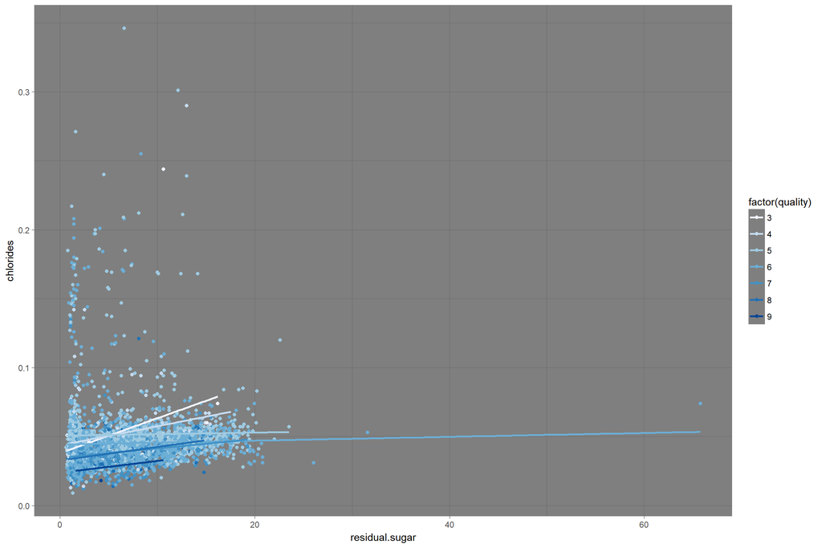

## 4.3. Volatile Acidity vs Citric Acid and Quality

Here we investigate volative acidity, which indicates the amount of acetic acid in wine, and citric acid. Acetic acid at too high of levels can lead to an unpleasant, vinegar taste while citric acid can add ‘freshness’ to wines. The presence of both acids will affect the pH levels. The graph shows that wines at exreme ends of rating occupy the moderate range of volatile acidity and citric acid. However, poor wines exhibit a positive correlation between volatile acidity and citric acid, while good winds axhibit a negative correlation between volatie acidity and citric acid. This indicates that the poor wines of this data set has high acetic acid content and high citric acid content, the acetic acid might have overpowered the citric acid taste. On the other hand, good wines strike a balance and have low acetic acid content with high citric acid content.

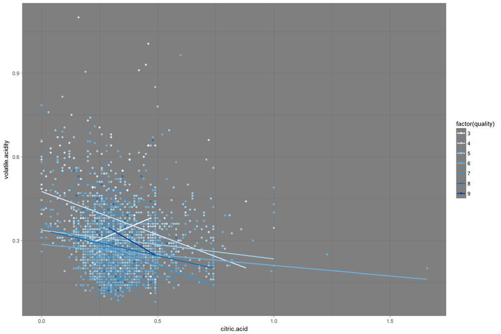

## 4.4. Model

Here I build a linear model expressing a relationship between quality and the various chemical properties. I also included log(sulphates) and log(residual.sugar) as these features seem to follow a normal distribution after conversion to a log scale. However, we see that the model does not explain the quality well with maximum R-squared as 0.283. This indicates that quality rating might be more subjective than thought or that the data cannot be modelled with a linear model.

```
##
## Calls:
## m1: lm(formula = quality ~ alcohol, data = ww)
## m2: lm(formula = quality ~ alcohol + I(log(sulphates)), data = ww)
## m3: lm(formula = quality ~ alcohol + I(log(sulphates)) + I(log(residual.sugar)),
##     data = ww)
## m4: lm(formula = quality ~ alcohol + I(log(sulphates)) + I(log(residual.sugar)) +
##     sulphates, data = ww)
## m5: lm(formula = quality ~ alcohol + I(log(sulphates)) + I(log(residual.sugar)) +
##     sulphates + residual.sugar, data = ww)
## m6: lm(formula = quality ~ alcohol + I(log(sulphates)) + I(log(residual.sugar)) +
##     sulphates + residual.sugar + chlorides, data = ww)
## m7: lm(formula = quality ~ alcohol + I(log(sulphates)) + I(log(residual.sugar)) +
##     sulphates + residual.sugar + chlorides + total.sulfur.dioxide,
##     data = ww)
## m8: lm(formula = quality ~ alcohol + I(log(sulphates)) + I(log(residual.sugar)) +
##     sulphates + residual.sugar + chlorides + total.sulfur.dioxide +
##     free.sulfur.dioxide, data = ww)
## m9: lm(formula = quality ~ alcohol + I(log(sulphates)) + I(log(residual.sugar)) +
##     sulphates + residual.sugar + chlorides + total.sulfur.dioxide +
##     free.sulfur.dioxide + density, data = ww)
## m10: lm(formula = quality ~ alcohol + I(log(sulphates)) + I(log(residual.sugar)) +
##     sulphates + residual.sugar + chlorides + total.sulfur.dioxide +
##     free.sulfur.dioxide + density + pH, data = ww)
## m11: lm(formula = quality ~ alcohol + I(log(sulphates)) + I(log(residual.sugar)) +
##     sulphates + residual.sugar + chlorides + total.sulfur.dioxide +
##     free.sulfur.dioxide + density + pH + citric.acid, data = ww)
## m12: lm(formula = quality ~ alcohol + I(log(sulphates)) + I(log(residual.sugar)) +
##     sulphates + residual.sugar + chlorides + total.sulfur.dioxide +
##     free.sulfur.dioxide + density + pH + citric.acid + volatile.acidity,
##     data = ww)
## m13: lm(formula = quality ~ alcohol + I(log(sulphates)) + I(log(residual.sugar)) +
##     sulphates + residual.sugar + chlorides + total.sulfur.dioxide +
##     free.sulfur.dioxide + density + pH + citric.acid + volatile.acidity +
##     fixed.acidity, data = ww)
##
## ================================================================================================================================================================================================================
##                                m1            m2            m3            m4            m5            m6            m7            m8            m9           m10           m11           m12           m13
## ----------------------------------------------------------------------------------------------------------------------------------------------------------------------------------------------------------------
##   (Intercept)                 2.582***      2.734***      2.178***      1.571**       1.563**       1.875***      2.030***      2.487***     86.835***    107.464***    118.080***    103.192***    140.766***
```

[output cut: 24 more lines]

```
##                                                                                                                                                                                        (0.114)       (0.114)
##   fixed.acidity                                                                                                                                                                                       0.059**
##                                                                                                                                                                                                      (0.021)
## ----------------------------------------------------------------------------------------------------------------------------------------------------------------------------------------------------------------
##   R-squared                   0.190         0.193         0.207         0.208         0.208         0.210         0.210         0.226         0.232         0.238         0.240         0.282         0.283
##   adj. R-squared              0.190         0.193         0.207         0.207         0.207         0.209         0.209         0.224         0.231         0.236         0.238         0.280         0.281
##   sigma                       0.797         0.796         0.789         0.789         0.789         0.788         0.788         0.780         0.777         0.774         0.773         0.751         0.751
##   F                        1146.395       586.251       426.846       320.510       256.510       216.711       186.097       178.150       164.073       152.449       140.296       159.891       148.410
##   p                           0.000         0.000         0.000         0.000         0.000         0.000         0.000         0.000         0.000         0.000         0.000         0.000         0.000
##   Log-likelihood          -5839.391     -5828.736     -5785.410     -5784.710     -5784.404     -5777.282     -5776.223     -5728.130     -5708.138     -5689.683     -5682.405     -5543.273     -5539.306
##   Deviance                 3112.257      3098.746      3044.407      3043.536      3043.156      3034.319      3033.008      2974.027      2949.847      2927.701      2919.014      2757.802      2753.339
##   AIC                     11684.782     11665.472     11580.821     11581.420     11582.807     11570.564     11570.446     11476.261     11438.275     11403.365     11390.810     11114.546     11108.613
##   BIC                     11704.272     11691.459     11613.304     11620.399     11628.283     11622.537     11628.916     11541.226     11509.738     11481.324     11475.265     11205.498     11206.061
##   N                        4898          4898          4898          4898          4898          4898          4898          4898          4898          4898          4898          4898          4898
## ================================================================================================================================================================================================================
```